# Group 7 Project 1: EDA

Group 7

3/24/2022

# 1. Intro

### 1.1 Data Set Overview

The Data Set is a fictional data set provided by IBM. It provides the demographic information on the customers of a telecommunications company, data on the services each customer used, charges paid (etc.), as well as whether the customer “churned” or not – meaning, whether the customer left the company. It also includes data on the reason(s) each customer who did leave gave for leaving.

### 1.2 SMART Questions

1. Which of the variables in the data set show a statistical difference between the churn and non-churn groupings?  
   -This will require doing 2-sample t-tests for continuous variables, and Chi Squared tests for categorical ones.  
   -If a variables passes its tests (i.e. p-value <= 0.05), that would suggest that it had a measurable effect on the decision to churn and can be used for modeling.
2. Of the variables that show a statistical difference between the churn and non-churn groupings, which are strong predictors of churn? -This will require creating model, for example, a logistical regression, and examining the adjusted r^2 value.  
   -This question will be answered in Project 2
3. Of the variables that are strong predictors of churn, which are actually providing useful information? -This will require critically thinking about what the variable is actually telling us.  
   -For example, it is likely that satisfaction score is more or less a corollary of churn and non-churn. Of course customers who churn are unsatisfied.  
   -Therefore, even though some variable might be strong predictors, they may not be actually helping us understand churn vs. non-churn.  
   -This question will be answered in Project 2

### 1.3 Report Organization and Analysis Steps

1. Prepare and describe data in data set
2. Divide into churn and non-churn groupings
3. Graph variables according to churn groupings to see if any obvious visual differences in the variables between churn groups
4. Conduct appropriate test for each variable to determine if there is a statistical difference between churn groups for each variable
5. Comment on results and propose next steps

# 2. Description of Data

### 2.1 Load data and join data sets

*Load Data Sets…*

```r
#Main data set
churn_df <- data.frame(read_csv('Data Files/Telco_customer_churn.csv', col_types=cols()))

#additional data sets
churn_status_df <- data.frame(read_csv('Data Files/Telco_customer_churn_demographics.csv', col_types = cols()))
churn_services_df <- data.frame(read_csv('Data Files/Telco_customer_churn_services.csv', col_types = cols()))
```

data set `churn_df` loaded…  
data set `churn_status_df` loaded…  
data set `churn_services_df` loaded…

*Join Data Sets…*

```r
status_join <- churn_status_df %>%
  select(c(Customer.ID))
#status_join

#Filer columns to join from services)df
service_join <- churn_services_df %>%
  select(c(Customer.ID, Avg.Monthly.Long.Distance.Charges, Avg.Monthly.GB.Download, Unlimited.Data, Total.Extra.Data.Charges))
#service_join

#Join status with churn
joined_churn_df <- merge(churn_df, status_join, by.x="CustomerID", by.y="Customer.ID")
#head(joined_churn_df)

#Join service with churn
joined_churn_df <- merge(joined_churn_df, service_join, by.x="CustomerID", by.y="Customer.ID")
#head(joined_churn_df)

head(joined_churn_df)
```

*data sets joined…*

### 2.2 Summary of data set structure

```r
#Note -- comment=NA removes the ## normally printed to output before each line

#drop unwanted columns from final df
filtered_joined_churn_df <- joined_churn_df %>%
  select(-c(1:10, 16, 20, 22:23, 28, 30:32))

#display structure of unfiltered df -- so can discuss what was added and dropped
str(joined_churn_df)
```

```
'data.frame':   7043 obs. of  37 variables:
 $ CustomerID                       : chr  "0002-ORFBO" "0003-MKNFE" "0004-TLHLJ" "0011-IGKFF" ...
 $ Count                            : num  1 1 1 1 1 1 1 1 1 1 ...
 $ Country                          : chr  "United States" "United States" "United States" "United States" ...
 $ State                            : chr  "California" "California" "California" "California" ...
 $ City                             : chr  "Frazier Park" "Glendale" "Costa Mesa" "Martinez" ...
 $ Zip.Code                         : num  93225 91206 92627 94553 93010 ...
 $ Lat.Long                         : chr  "34.827662, -118.999073" "34.162515, -118.203869" "33.645672, -117.922613" "38.014457, -122.115432" ...
 $ Latitude                         : num  34.8 34.2 33.6 38 34.2 ...
 $ Longitude                        : num  -119 -118 -118 -122 -119 ...
 $ Gender                           : chr  "Female" "Male" "Male" "Male" ...
 $ Senior.Citizen                   : chr  "No" "No" "No" "Yes" ...
 $ Partner                          : chr  "Yes" "No" "No" "Yes" ...
 $ Dependents                       : chr  "No" "No" "No" "No" ...
 $ Tenure.Months                    : num  9 9 4 13 3 9 71 63 7 65 ...
```

[output cut: 23 more lines]

**Selecting Variables**

The initial churn data frame `(Telco_customer_churn.csv)` contained 33 variables. Another 4 variables were added from the `Telco_customer_churn_services.csv` and 0 variables from the `Telco_customer_churn_status.csv` data set. Conversely, 18 variables were dropped/not examined from the original `Telco_customer_churn.csv` data frame. The specific variables added and dropped, and the reason for doing so, follow below:

**Added Variables**

*From `Telco_customer_churn_status.csv`*

*From `Telco_customer_churn_services.csv`*

- `Avg.Monthly.Long.Distance.Charges`
- `Avg.Monthly.GB.Download`
- `Unlimited.Data`
- `Total.Extra.Data.Charges`

**Dropped/Not Examined Varaibles**

*From `Telco_customer_churn.csv`*

- `CustomerID` [not relevant]
- `Count` [useful to ensure uniqueness, but otherwise not relevant]
- `Country` [location data not examined]
- `State` [location data not examined]
- `City` [location data not examined]
- `Zip.Code` [location data not examined]
- `Lat.Long` [location data not examined]
- `Latitude` [location data not examined]
- `Longitude` [location data not examined]
- `Gender` [not relevant]
- `Multiple.Lines` [assumed corollary with phone service, extra charge from more lines connected with monthly charges]
- `Device.Protection`
- `Streaming.TV` [assumed corollary with GB download and internet speed (type)]
- `Streaming.Movies` [assumed corollary with GB download and internet speed (type)]
- `Total.Charges` [assumed corollary with monthly charges]
- `Churn.Value` [Same as churn label]
- `Churn.Score` [this is ultimately what we are trying to determine!]
- `CLTV` [not examining profit, monthly charge more relevant for our purposes]

Most of the variables that were not examined were ignored because they appeared obviously irrelevant, correlated with other variables, or did not seem to provide helpful information with respect to the questions we are trying to answer. Specifically regarding location data, while examining location data could prove useful, it was decided to use it for follow up analysis. Part of the reason it was not chosen for the primary analysis is this data set does not contain data to dig further into what results on location analysis might mean. We don’t have, for example, data on the strength of cell phone networks or availability of internet types by zip code, so it would be hard to usefully connect location data with other data and results.

The final data frame, `filtered_joined_churn_df`, consists of 19 variables.

### 2.3 Display joined and filted data set

```r
# filtered_joined_churn_df <- joined_churn_df %>%
#   select(-c(1:10, 16, 20, 22:23, 28, 30:33))

#display final filtered df
DT::datatable(filtered_joined_churn_df,
         extensions = c('FixedColumns',"FixedHeader"),
          options = list(scrollX = TRUE,
                         paging=TRUE,
                         fixedHeader=TRUE))
```

|  | Senior.Citizen | Partner | Dependents | Tenure.Months | Phone.Service | Internet.Service | Online.Security | Online.Backup | Tech.Support | Contract | Paperless.Billing | Payment.Method | Monthly.Charges | Churn.Label | Churn.Reason | Avg.Monthly.Long.Distance.Charges | Avg.Monthly.GB.Download | Unlimited.Data | Total.Extra.Data.Charges |
| --- | --- | --- | --- | --- | --- | --- | --- | --- | --- | --- | --- | --- | --- | --- | --- | --- | --- | --- | --- |
| 1 | No | Yes | No | 9 | Yes | DSL | No | Yes | Yes | One year | Yes | Mailed check | 65.6 | No |  | 42.39 | 16 | Yes | 0 |
| 2 | No | No | No | 9 | Yes | DSL | No | No | No | Month-to-month | No | Mailed check | 59.9 | No |  | 10.69 | 10 | No | 10 |
| 3 | No | No | No | 4 | Yes | Fiber optic | No | No | No | Month-to-month | Yes | Electronic check | 73.9 | Yes | Price too high | 33.65 | 30 | Yes | 0 |
| 4 | Yes | Yes | No | 13 | Yes | Fiber optic | No | Yes | No | Month-to-month | Yes | Electronic check | 98 | Yes | Product dissatisfaction | 27.82 | 4 | Yes | 0 |
| 5 | Yes | Yes | No | 3 | Yes | Fiber optic | No | No | Yes | Month-to-month | Yes | Mailed check | 83.9 | Yes | Network reliability | 7.38 | 11 | Yes | 0 |
| 6 | No | No | Yes | 9 | Yes | DSL | No | No | Yes | Month-to-month | Yes | Credit card (automatic) | 69.4 | No |  | 16.77 | 73 | Yes | 0 |
| 7 | Yes | Yes | No | 71 | Yes | Fiber optic | Yes | Yes | Yes | Two year | Yes | Bank transfer (automatic) | 109.7 | No |  | 9.96 | 14 | Yes | 0 |
| 8 | No | Yes | No | 63 | Yes | Fiber optic | Yes | No | Yes | Two year | Yes | Credit card (automatic) | 84.65 | No |  | 12.96 | 7 | No | 20 |
| 9 | Yes | No | No | 7 | Yes | DSL | Yes | No | No | Month-to-month | Yes | Electronic check | 48.2 | No |  | 10.53 | 21 | Yes | 0 |
| 10 | No | Yes | Yes | 65 | Yes | DSL | Yes | Yes | Yes | Two year | Yes | Mailed check | 90.45 | No |  | 28.46 | 14 | Yes | 0 |

[output cut: 7033 more lines]

```r
#xkabledplyhead(joined_churn_df, title = "Churn Data Set")
```

# 3. Examine Data

### 3.1 Loading functions to use for analysis

```r
#Create updated xkable_summary function to delete unwanted text
xkablesum_updated <- function (df, title = "Table: Statistics summary.", digits = 4,
          pos = "left", bso = "striped")
{
    s = summary(df)

    # Including RE NA's strip
    # Needed to add a dim check because including NA strip when no NA row made a new 7th row with text Min.:
    if (dim(s)[1] == 6) {
      strip_vector = c("Min.\\s*:\\s*", "1st Qu.\\s*:\\s*", "Median\\s*:\\s*", "Mean\\s*:\\s*",
                       "3rd Qu.\\s*:\\s*", "Max.\\s*:\\s*")
    }
    # NA's strip RE added here
    else if (dim(s)[1] == 7) {
      strip_vector = c("Min.\\s*:\\s*", "1st Qu.\\s*:\\s*", "Median\\s*:\\s*", "Mean\\s*:\\s*",
                       "3rd Qu.\\s*:\\s*", "Max.\\s*:\\s*", "NA's\\s*:\\s*")
    }

    # Made s = apply() -- without, didn't apply changes to table
    s <- apply(s, 2, function(x) stringr::str_remove_all(x, strip_vector))

    # Made s = apply()
    s <- apply(s, 2, function(x) stringr::str_trim(x, "right"))
    colnames(s) <- stringr::str_trim(colnames(s))

    if (dim(s)[1] == 6) {
        rownames(s) <- c("Min", "Q1", "Median",
                         "Mean", "Q3", "Max")
    }
    else if (dim(s)[1] == 7) {
        rownames(s) <- c("Min", "Q1", "Median",
                         "Mean", "Q3", "Max", "NA")
    }
    xkabledply(s, title = title, digits = digits, pos = pos,
               bso = bso)
}

#Better looking version of 2-sample t-test results than what the object itself displays
ttest2sample_info <- function(test) {
  if (test[["p.value"]] <= 0.05) {
  result = 'Reject the Null Hypothesis'
  } else {
    result = 'Do not reject the Null Hypothesis'
  }

  cat(c('\t', test$method, '\n\n',
      'Data:                       ', '|   ', test$data.name, '\n',
      'Null Hypothesis:            ', '|   true difference in means = ', test$null.value[1], '\n',
      'Alternative Hypothesis:     ', '|   true difference in means != ', test$null.value[1], '\n',
      'Confidence Level:           ', '|   ', attributes(test$conf.int)$conf.level, '\n',
      'Confidence Interval:        ', '|   [', round(test$conf.int[1], 2), ', ', round(test$conf.int[2], 2)), ']\n',
      'Sample Estimates of Mean:   ', '|   [X = ', test$estimate[1], ', Y = ', test$estimate[2], ']\n',
      'Test Values:                ', '|   [t = ', test$statistic,
                                   ', |   df = ', test$parameter[1],
                                   ', |   p-value = ', test[["p.value"]], ']\n',
      'Result:                     ', '|   ', result, sep='')
}
```

*functions loaded…*

```r
#Display summary statistics of continuous variables for entire df
```

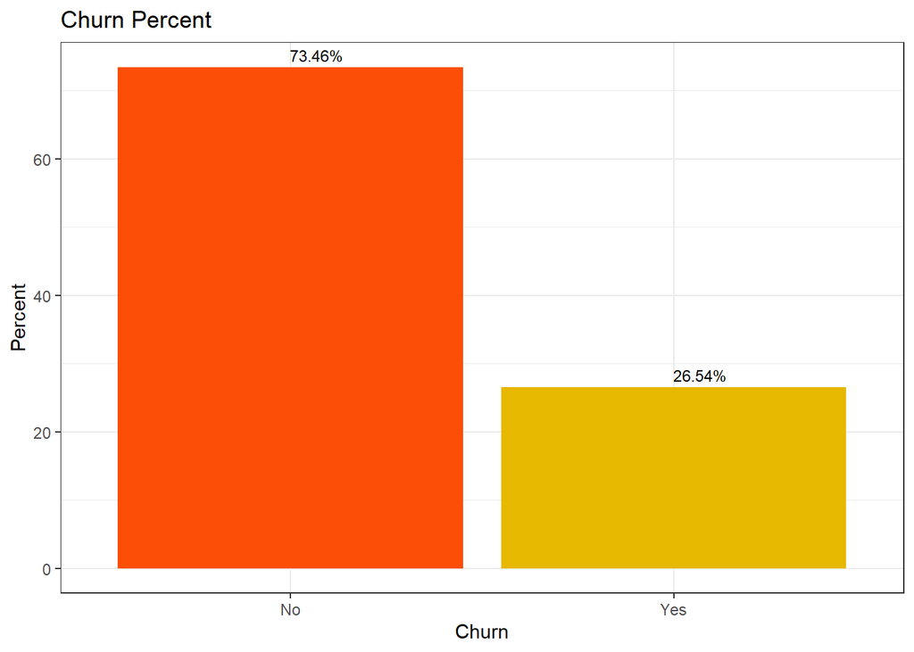

```r
options(repr.plot.width = 6, repr.plot.height = 4)
joined_churn_df %>%
group_by(Churn.Label) %>%
summarise(Count = n())%>%
mutate(percent = prop.table(Count)*100)%>%
ggplot(aes(reorder(Churn.Label, -percent), percent), fill = Churn)+
geom_col(fill = c("#FC4E07", "#E7B800"))+
geom_text(aes(label = sprintf("%.2f%%", percent)), hjust = 0.01,vjust = -0.5, size =3)+
theme_bw()+
xlab("Churn") +
ylab("Percent")+
ggtitle("Churn Percent")
```

* around 26% of ustomer left the platform within the last month.

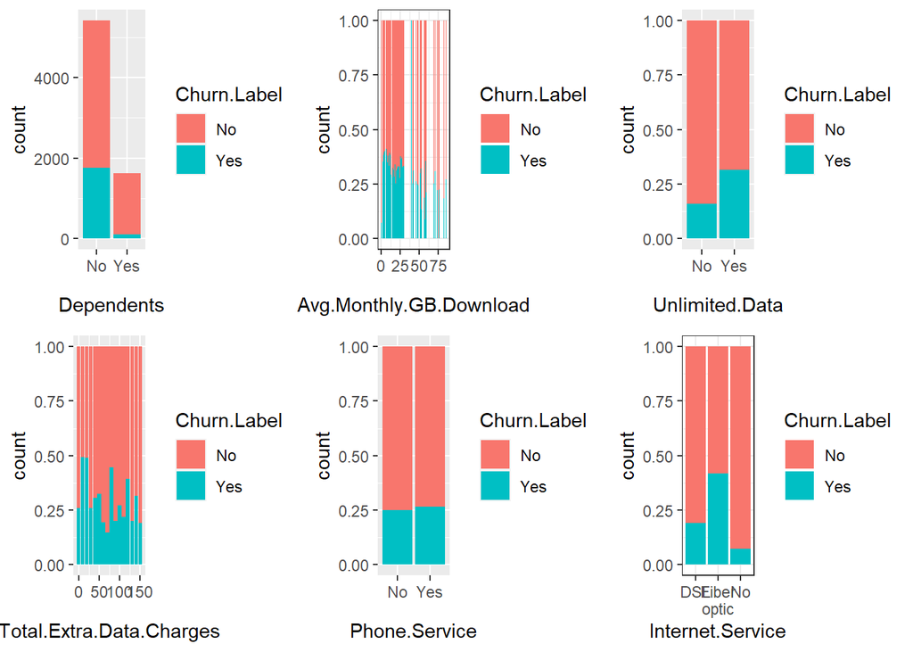

```r
options(repr.plot.width = 12, repr.plot.height = 8)
plot_grid(ggplot(joined_churn_df, aes(x=Dependents,fill=Churn.Label))+ geom_bar(),ggplot(joined_churn_df, aes(x=Avg.Monthly.GB.Download,fill=Churn.Label))+ geom_bar(position = 'fill')+theme_bw(),
          ggplot(joined_churn_df, aes(x=Unlimited.Data,fill=Churn.Label))+ geom_bar(position = 'fill'),
          ggplot(joined_churn_df, aes(x=Total.Extra.Data.Charges,fill=Churn.Label))+ geom_bar(position = 'fill'),
          ggplot(joined_churn_df, aes(x=Phone.Service,fill=Churn.Label))+ geom_bar(position = 'fill'),
          ggplot(joined_churn_df, aes(x=Internet.Service,fill=Churn.Label))+ geom_bar(position = 'fill')+theme_bw()+
          scale_x_discrete(labels = function(x) str_wrap(x, width = 10)),
          align = "h")
```

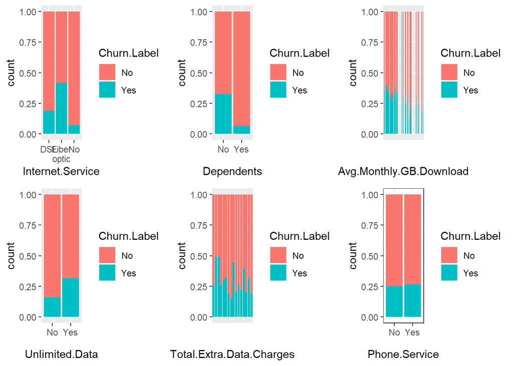

```r
options(repr.plot.width = 12, repr.plot.height = 8)
plot_grid(ggplot(joined_churn_df, aes(x=Internet.Service,fill=Churn.Label))+ geom_bar(position = 'fill')+
          scale_x_discrete(labels = function(x) str_wrap(x, width = 10)),
          ggplot(joined_churn_df, aes(x=Dependents,fill=Churn.Label))+ geom_bar(position = 'fill')+
          scale_x_discrete(labels = function(x) str_wrap(x, width = 10)),
          ggplot(joined_churn_df, aes(x=Avg.Monthly.GB.Download,fill=Churn.Label))+ geom_bar(position = 'fill')+
          scale_x_discrete(labels = function(x) str_wrap(x, width = 10)),
          ggplot(joined_churn_df, aes(x=Unlimited.Data,fill=Churn.Label))+ geom_bar(position = 'fill')+
          scale_x_discrete(labels = function(x) str_wrap(x, width = 10)),
          ggplot(joined_churn_df, aes(x=Total.Extra.Data.Charges,fill=Churn.Label))+ geom_bar(position = 'fill')+
          scale_x_discrete(labels = function(x) str_wrap(x, width = 10)),
          ggplot(joined_churn_df, aes(x=Phone.Service,fill=Churn.Label))+ geom_bar(position = 'fill')+theme_bw()+
          scale_x_discrete(labels = function(x) str_wrap(x, width = 10)),
          align = "h")
```